# FLAUDIT: Flywheel Project Audit

## Project: gear_testing

# Sequences

Here’s a list of all the sequences in gear_testing:

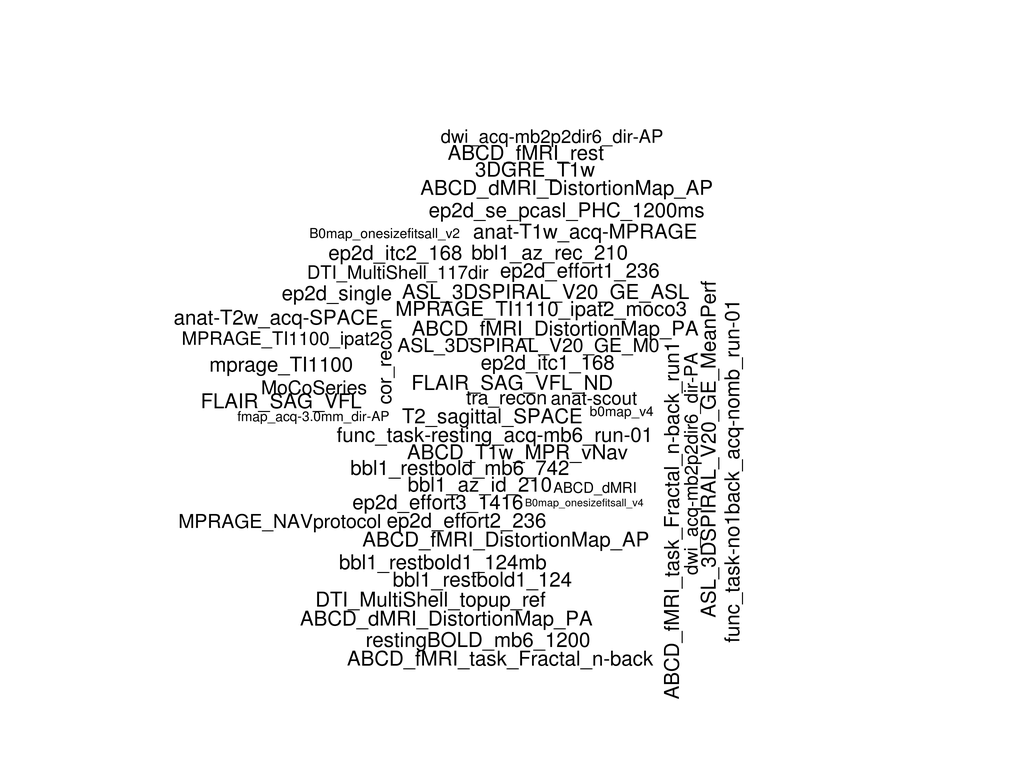

|  | . | Freq |
| --- | --- | --- |
| 1 | B0map_onesizefitsall_v4 | 11 |
| 2 | B0map_onesizefitsall_v2 | 8 |
| 3 | b0map_v4 | 8 |
| 4 | fmap_acq-3.0mm_dir-AP | 8 |
| 5 | ABCD_dMRI | 7 |
| 6 | anat-scout | 3 |
| 7 | DTI_MultiShell_117dir | 3 |
| 8 | dwi_acq-mb2p2dir6_dir-AP | 3 |
| 9 | dwi_acq-mb2p2dir6_dir-PA | 3 |
| 10 | MPRAGE_TI1100_ipat2 | 3 |

[output cut: 39 more lines]

We visualise the above frequencies below:

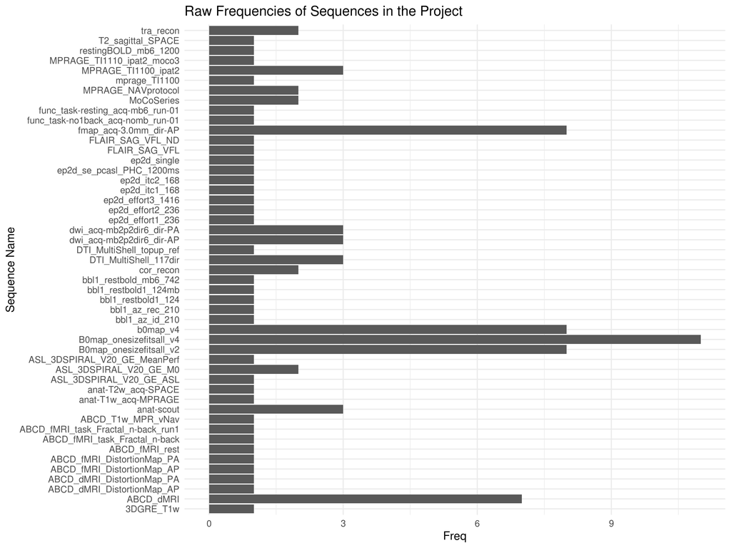

And hence, the missingness of sequences across all the subjects in gear_testing:

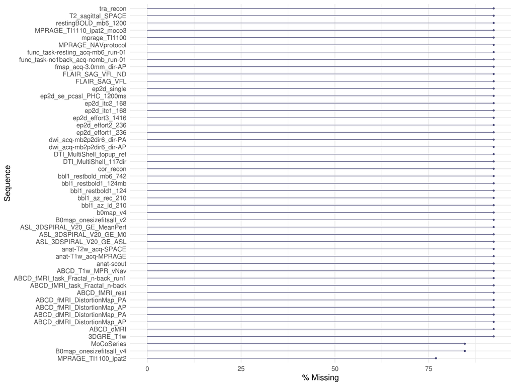

# BIDS Curation

The tree diagram below shows how each sequence has been curated into BIDS format. The leaf at the end of each branch counts how many subjects have files that fall under each BIDS template.

[interactive chart not shown]

|  | series_description | bids_name | Freq |
| --- | --- | --- | --- |
| 1 | B0map_onesizefitsall_v4 | {subject}_{session}_fieldmap.nii.gz | 11 |
| 2 | B0map_onesizefitsall_v2 | {subject}_{session}_fieldmap.nii.gz | 8 |
| 3 | b0map_v4 | {subject}_{session}_fieldmap.nii.gz | 8 |
| 4 | fmap_acq-3.0mm_dir-AP | {subject}_{session}_acq-30mm_dir-AP_epi__dup-01.nii.gz | 8 |
| 5 | ABCD_dMRI | {subject}_{session}_dwi.bval | 2 |
| 6 | ABCD_dMRI | {subject}_{session}_dwi.bvec | 2 |
| 7 | ABCD_dMRI | {subject}_{session}_dwi.nii.gz | 2 |
| 8 | anat-scout | {subject}_{session}_scout__dup-02.nii.gz | 2 |
| 9 | ASL_3DSPIRAL_V20_GE_M0 | {subject}_{session}_m0.nii.gz | 2 |
| 10 | MPRAGE_NAVprotocol | {subject}_{session}_T1w.nii.gz | 2 |

[output cut: 53 more lines]

# Gears and Jobs

Here are the raw counts of complete gear runs, using only the most recent version and run of each gear:

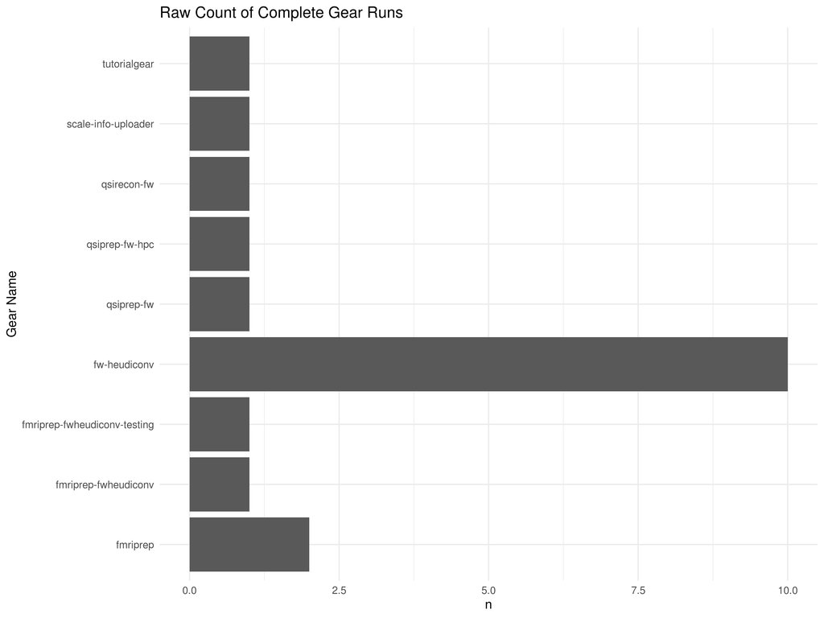

Here are the gear completion statistics:

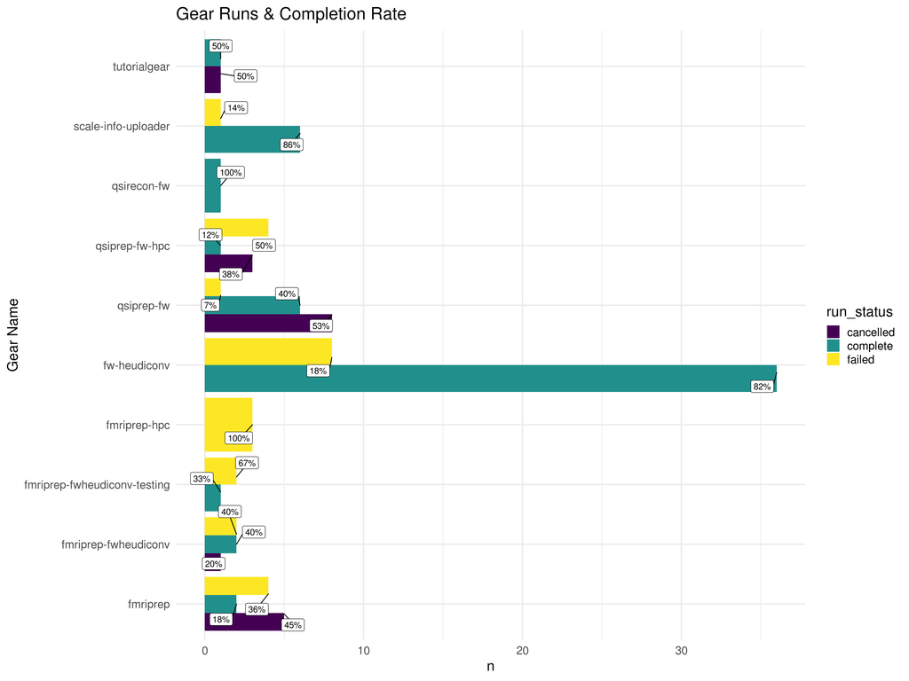

# Gear Runtime

Below are the runtimes of gear runs:

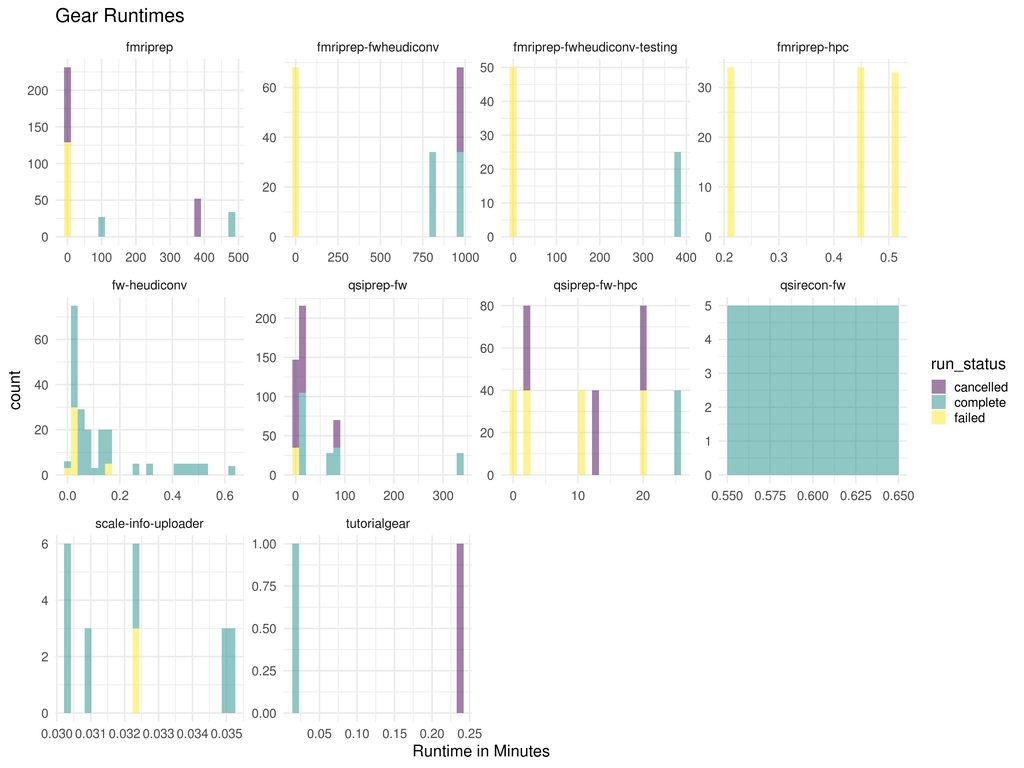

# Workflow of Curation & Analysis Gears

[interactive chart not shown]

# Attachments

There are 88 attachments for a total of 450 MB of data.

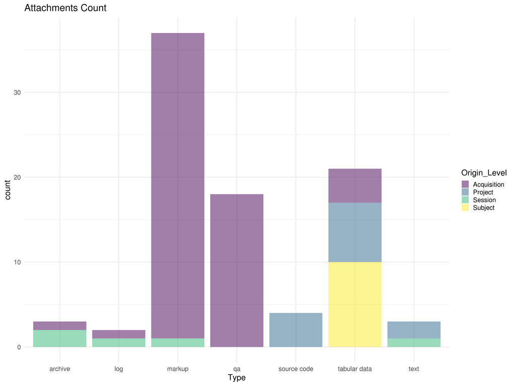